# 10. Data Wangling & Cleaning

# 10.5.3 Reducing the number of categories

```python
df.origin.value_counts(normalize=True)
```

```
Google               0.311604
Direct Traffic       0.276293
Olark Chat           0.190678
Organic Search       0.125380
Reference            0.058018
Welingak Website     0.015428
Referral Sites       0.013581
Facebook             0.005976
bing                 0.000652
google               0.000543
Click2call           0.000435
Press_Release        0.000217
Social Media         0.000217
Live Chat            0.000217
NC_EDM               0.000109
welearnblog_Home     0.000109
blog                 0.000109
Pay per Click Ads    0.000109
testone              0.000109
youtubechannel       0.000109
WeLearn              0.000109
Name: origin, dtype: float64
```

```python
df['origin']= df.origin.str.lower()
```

```python
df.origin.value_counts(normalize=True)[df.origin.value_counts(normalize=True) < .1].index
```

```
Index(['reference', 'welingak website', 'referral sites', 'facebook', 'bing',
       'click2call', 'live chat', 'press_release', 'social media',
       'welearnblog_home', 'blog', 'testone', 'youtubechannel', 'nc_edm',
       'pay per click ads', 'welearn'],
      dtype='object')
```

```python
smalls= df.origin.value_counts(normalize=True)[df.origin.value_counts(normalize=True) < .1].index.tolist()
```

```python
small_map= dict(zip(smalls, (len(smalls)*'others ').split(' ')[:-1]))
```

```python
dict(zip(smalls, (len(smalls)*'others ').split(' ')[:-1]))
```

```
{'bing': 'others',
 'blog': 'others',
 'click2call': 'others',
 'facebook': 'others',
 'live chat': 'others',
 'nc_edm': 'others',
 'pay per click ads': 'others',
 'press_release': 'others',
 'reference': 'others',
 'referral sites': 'others',
 'social media': 'others',
 'testone': 'others',
 'welearn': 'others',
 'welearnblog_home': 'others',
 'welingak website': 'others',
 'youtubechannel': 'others'}
```

```python
df['origin']= df.origin.map(small_map).fillna(df.origin)
```

```python
df.origin.value_counts()
```

```
google            2873
direct traffic    2543
olark chat        1755
organic search    1154
others             879
Name: origin, dtype: int64
```

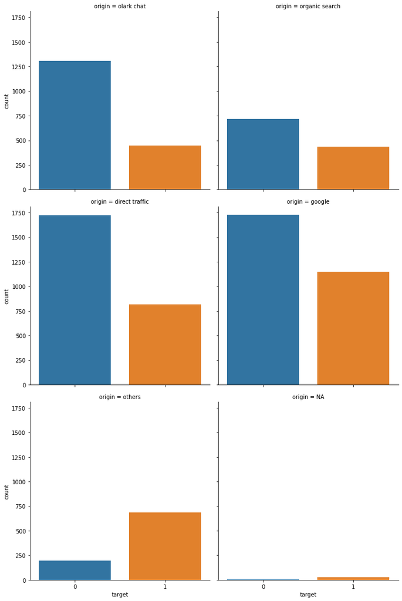

```python
sns.catplot(x="target", col="origin", col_wrap=2,
                data=df.fillna('NA'),
                kind="count", height=5, aspect=1)
```

# 10.6 Methods not covered

The following references are being offered to the class aas these haven't been covered in the class due to the data set or the advanced nature.

You may want to take look an see if you need them for your Term Project

1. [Parsing dates](https://www.kaggle.com/alexisbcook/parsing-dates)
2. [Character Encoding Challenges](https://www.kaggle.com/alexisbcook/character-encodings)
3. [Human Error in Data Entry](https://www.kaggle.com/alexisbcook/inconsistent-data-entry)
4. [Cleaning text data](https://www.dataquest.io/blog/regular-expressions-data-scientists/)
5. [Another one on text data](https://johnathan-d-padilla.medium.com/an-introduction-to-data-cleaning-using-regular-expressions-to-clean-your-data-9684ccfac74c)